# Methanogen Data

Chiara Corbo Galli

2024-12-11

# Contact Information

chiaracorbo-galli2025@u.northwestern.edu

# Background

This is an html rendering containing all data in the project, broken down to allow for easier comparisions. It also includes some additional information regarding techniques, etc. that did not make it onto the poster, but might be relevant for others seeking to recreate the study.

## Important Terminology

Time points:

T0 = day of inoculation

T1 = 21 days post inoculation

T2 = 33 days ’’

T3 = 46 days ’’

T4 = 69 days ’’

T5 = 140 days ’’

## Methods

### DAPI

Dapi counts were performed using a DAPI concentrationof 0.005mg/ml of DAPI. Samples were extracted at their corresponding time and fixed using a PFA solution. Once samples were ready to be counted, they were incoculated for 10minutes with a DAPI solution before being visualized with a compound microscope at 1000x magnification (cells were very small)

### DIC isotope and concentration

A calibration curve was calculated using a 10mM NHC solution of varying ml amounts. This allowed for a calculation of DIC concentration. For isotope analysis, a filtering system of good peaks was utilized with a max stdev of 0.15, a minimum peak area of 1, and a minimum peak number of 3

# All Data

This is a compilation of all the data points together, for just based on inoculum type see other document sections

## Cell Counts

#### Individual Counts and average counts from DAPI

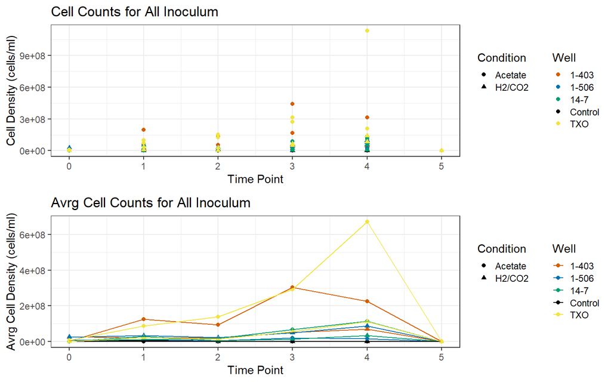

## δ13C DIC

#### DIC δ13C data

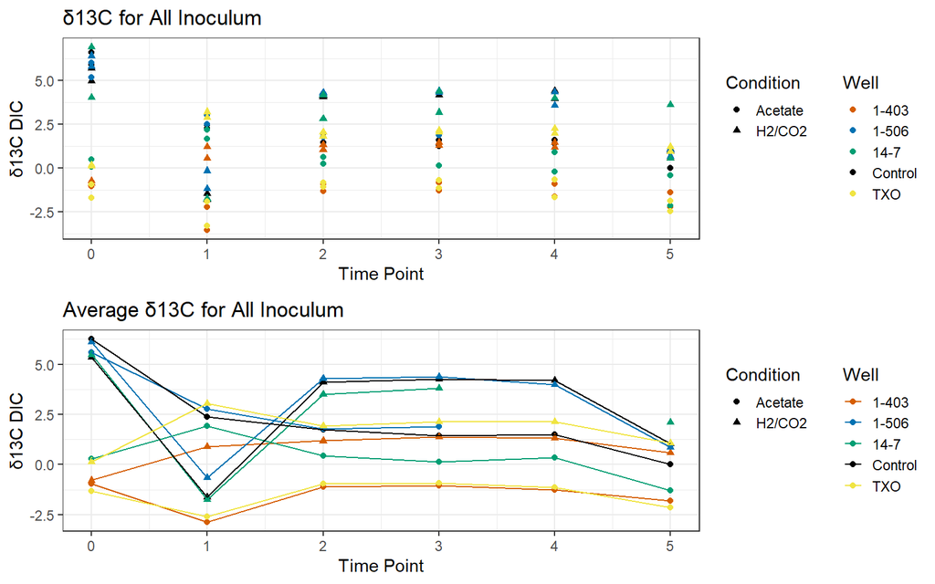

## Methane Concentration

#### GC obtained methane concentration from bottles

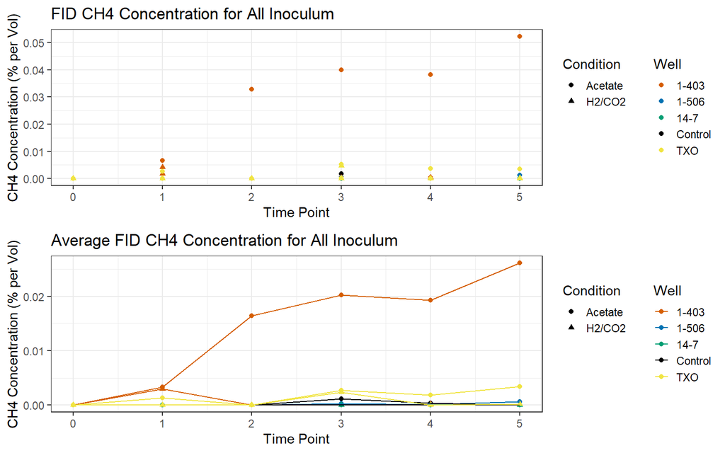

## DIC Concentration

#### DIC Concentration from Samples w. NHC 10mM standard

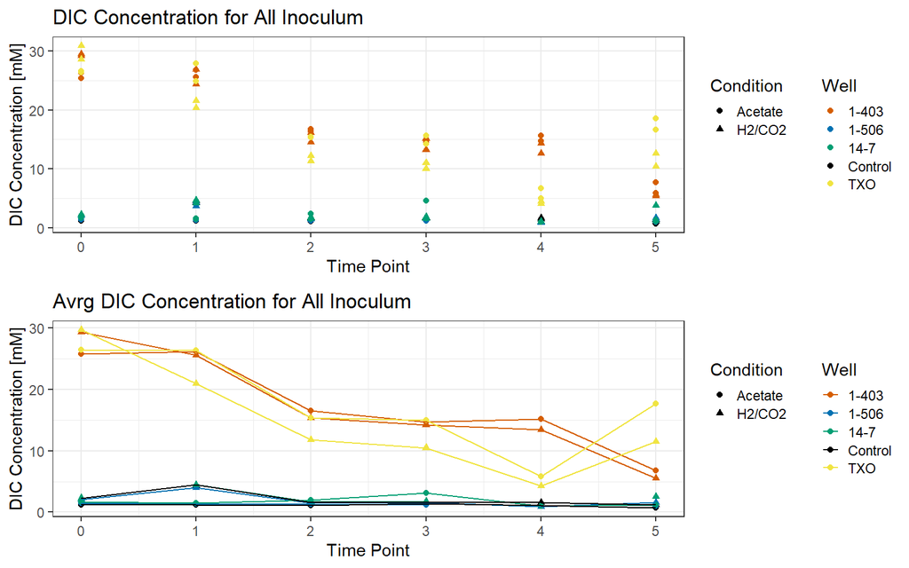

## Compiled Plot

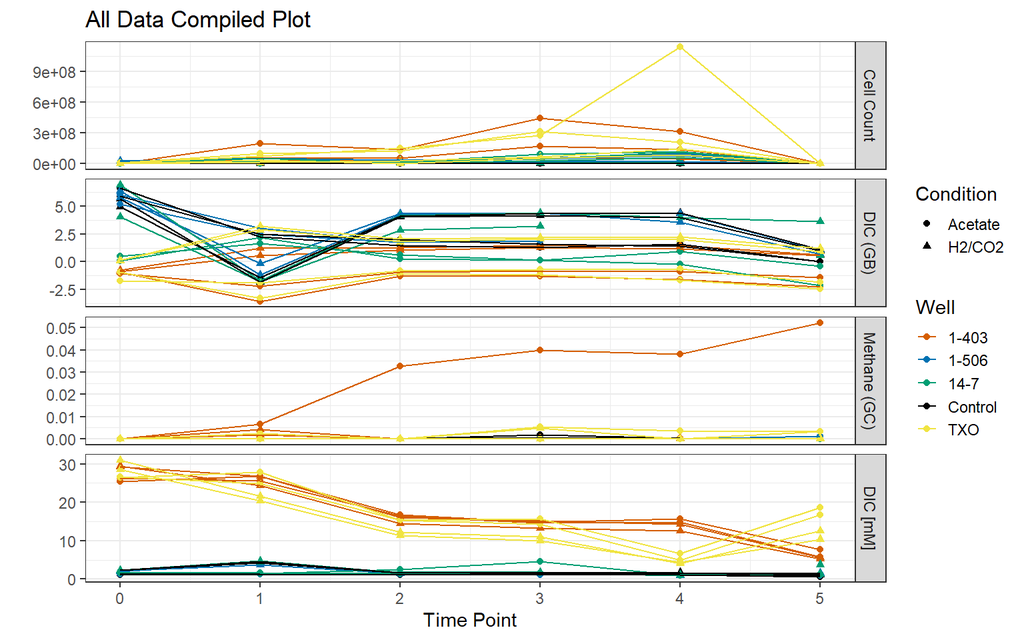

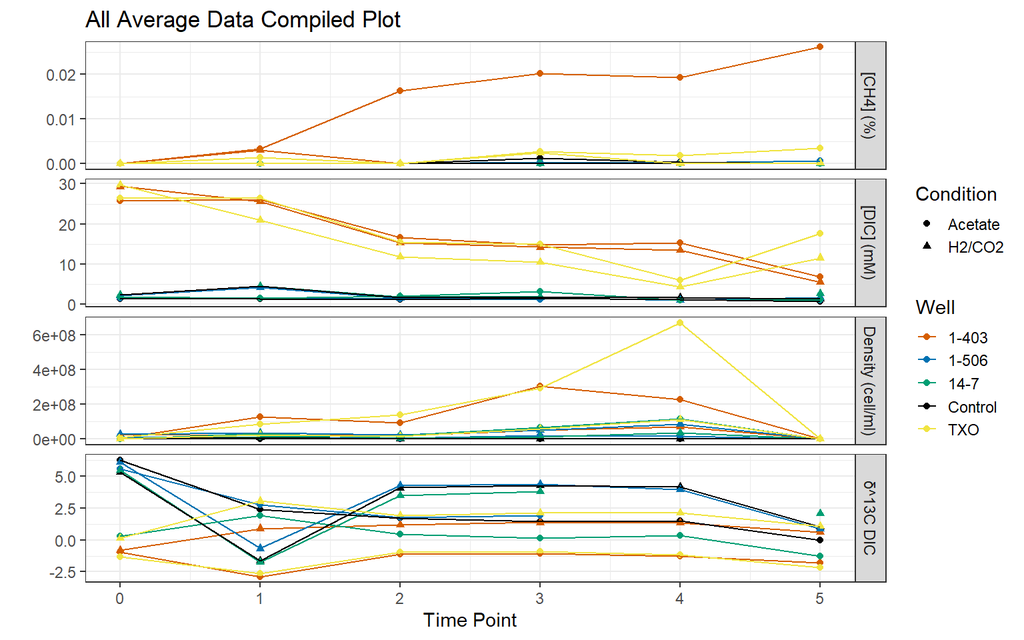

# Acetate Data

### This is data for the acetate condition only

## Cell Counts

#### Individual Counts and average counts from DAPI

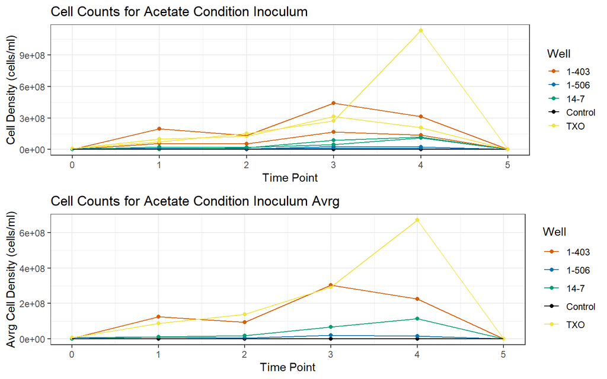

## δ13C DIC

#### DIC δ13C data

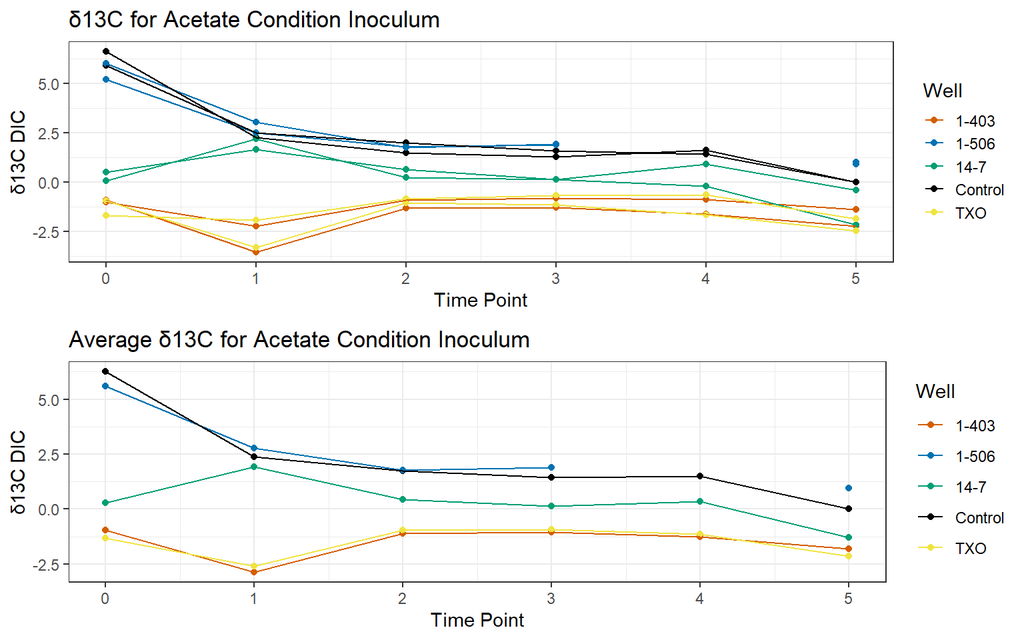

## Methane Concentration

#### GC obtained methane concentration from bottles

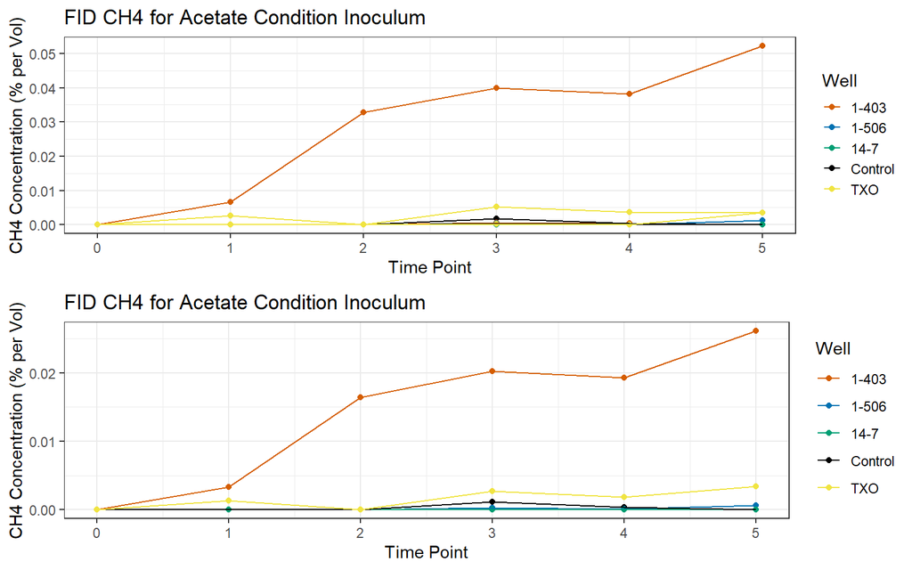

## DIC Concentration

#### DIC Concentration from Acetate Samples w. NHC 10mM standard

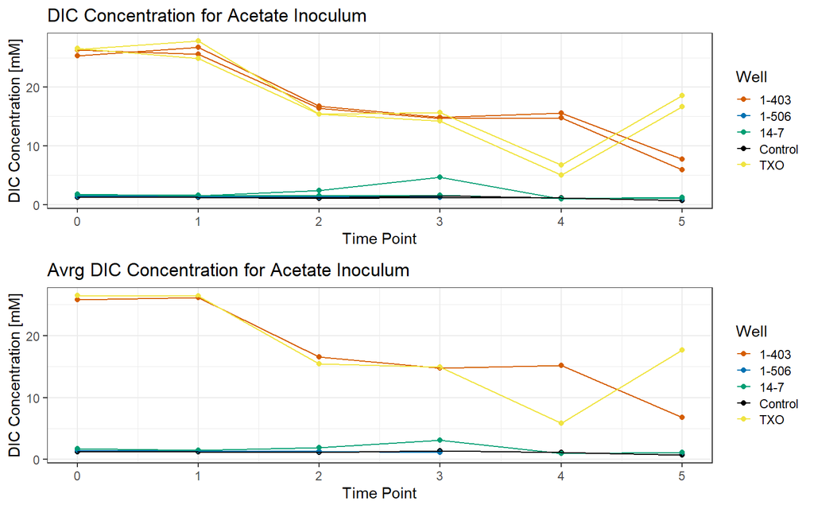

## Compiled Plot

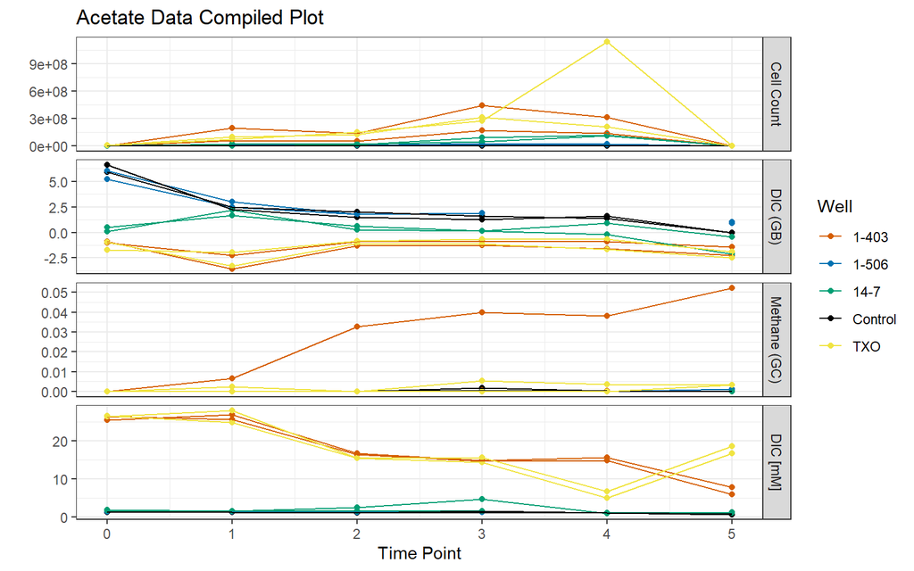

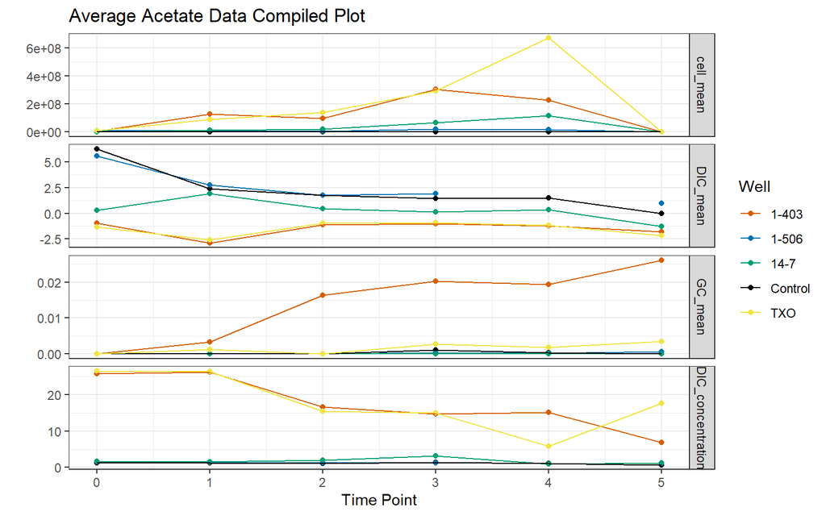

# H2/CO2 Data

#### Data for just the H2/CO2 condition bottles

## Cell Counts

#### Individual Counts and average counts from DAPI

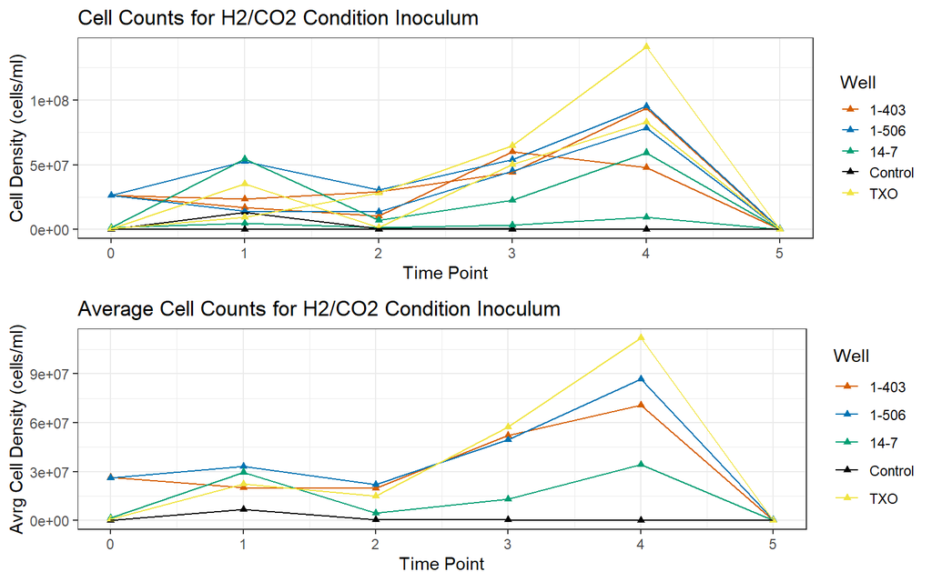

## δ13C DIC

#### DIC δ13C data

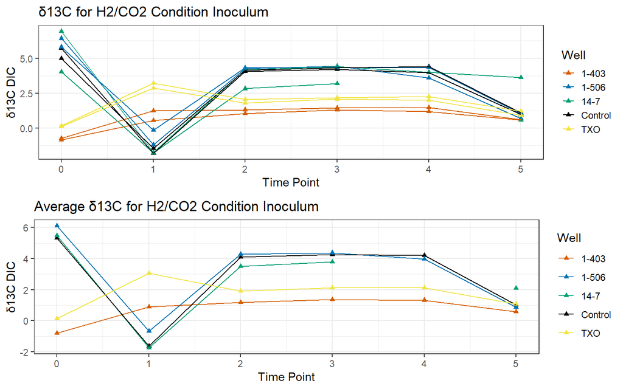

## Methane Concentration

#### GC obtained methane concentration from bottles

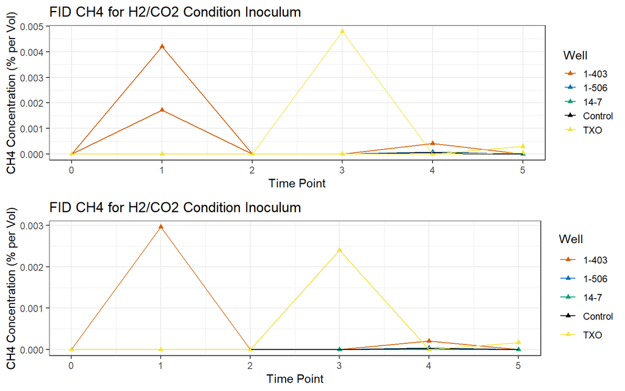

## DIC Concentration

#### DIC Concentration from H2/CO2 Samples w. NHC 10mM standard

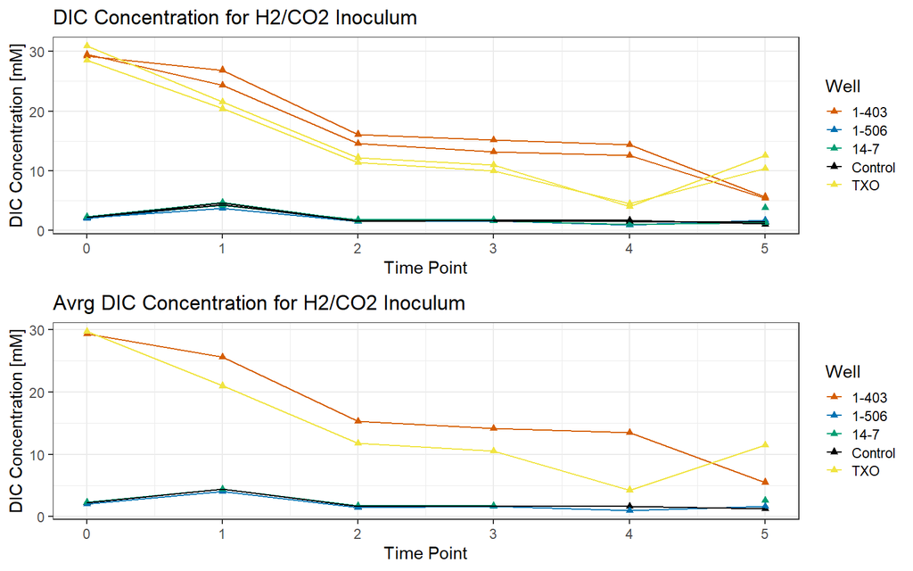

## Compiled Plot

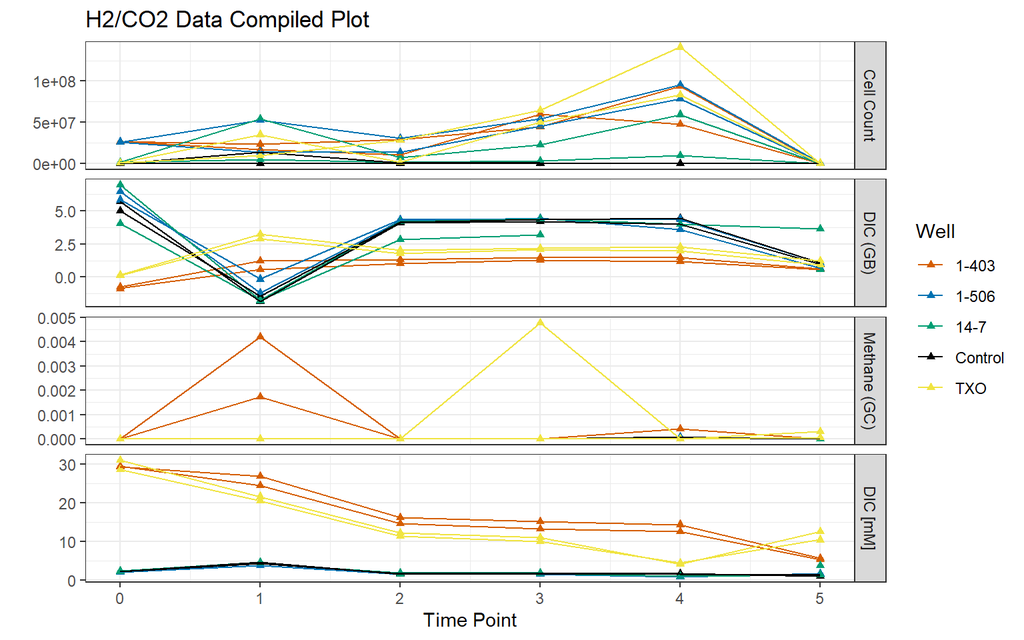

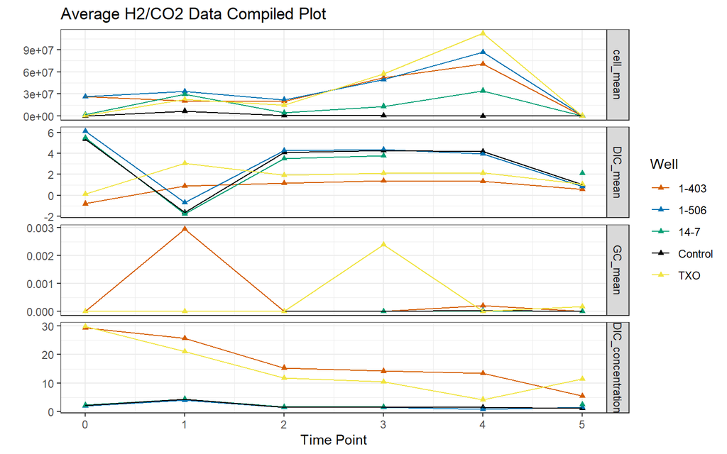

# DIC Plots

### These are DIC [mM] vs δ13C DIC for H2/CO2 and Acetate conditions (averages), broken down by time point

## T0

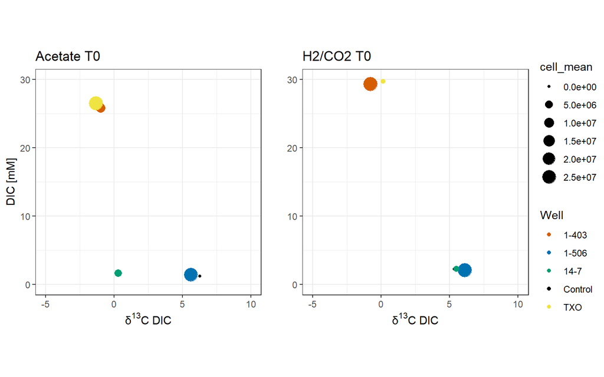

## T1

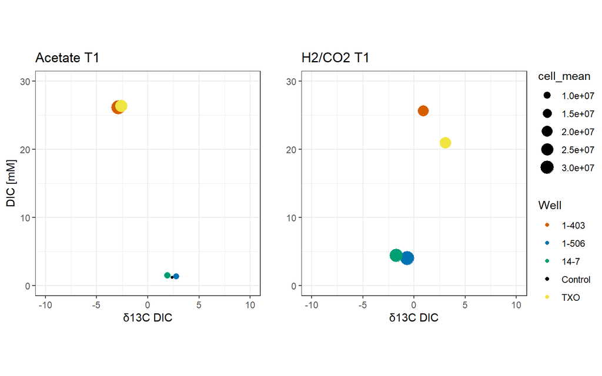

## T2

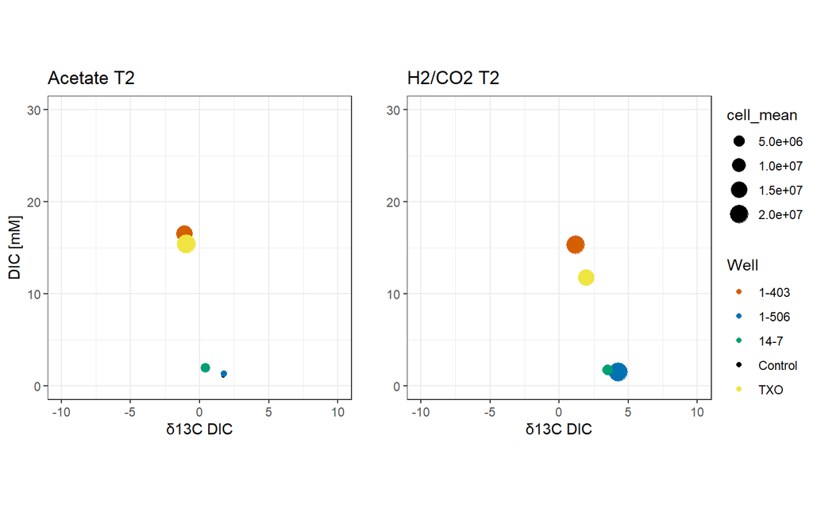

## T3

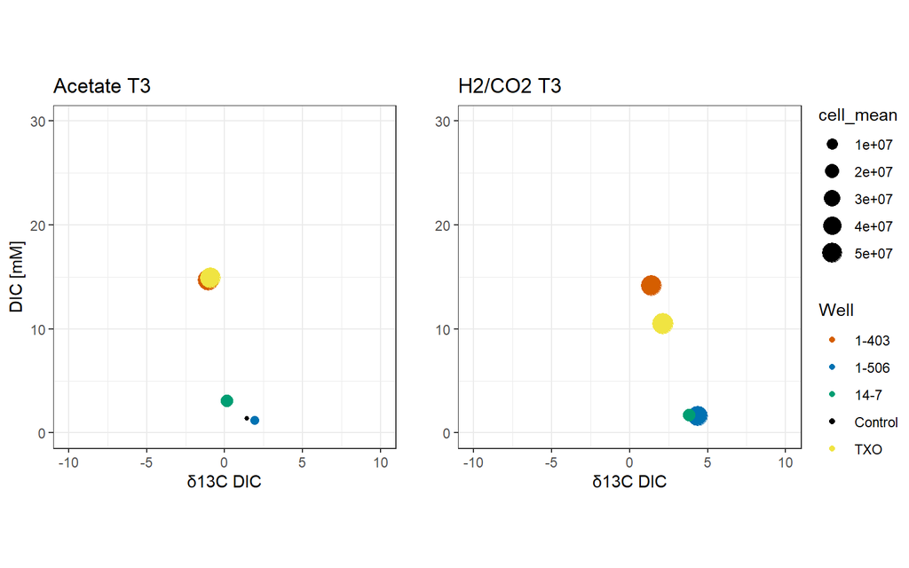

## T4

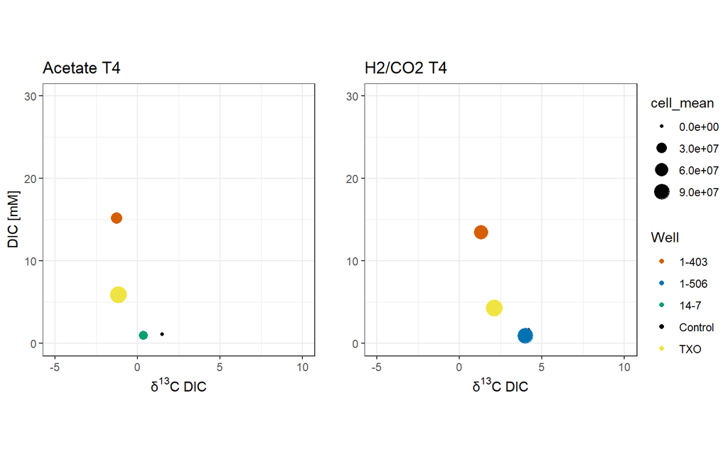

## T5

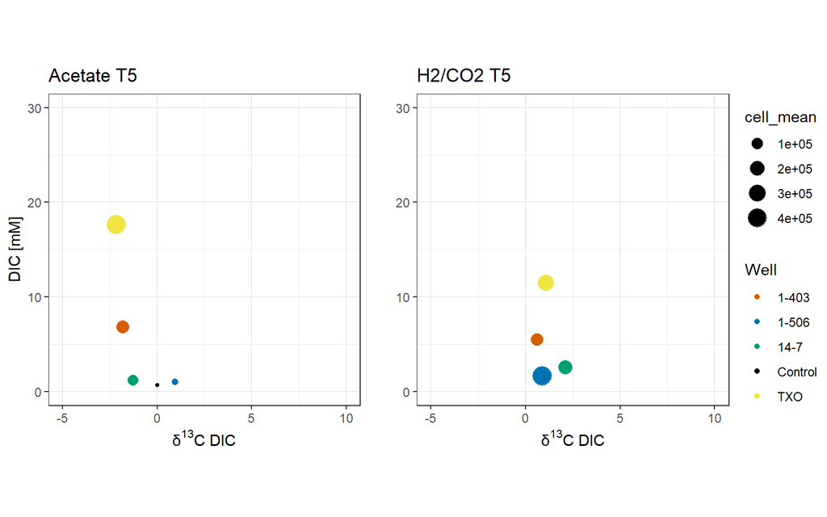

## Combined DIC Plot

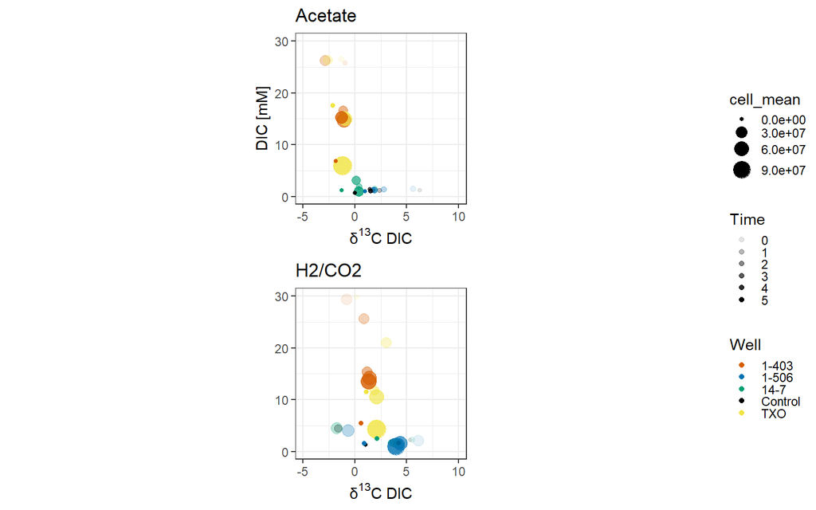